# Predicting Credit Risk

## 6.5 Neural Networks

Les réseaux neuronaux sont l’un des modèles d’apprentissage machine les plus fascinants car leur structure inspirée par le cerveau.

Neural Network

method = ‘nnet’

Type: Classification, Regression

Tuning parameters:

- size (#Hidden Units)
  - decay (Weight Decay)

Required packages: nnet

A model-specific variable importance metric is available.

#### Fine-Tuning recherche des Hyperparameters avec Cross validation et grid search

```r
start_timenet = Sys.time()
set.seed(400)
ctrl <- trainControl(method="cv",number = 2, search = "grid")

my.grid <- expand.grid(size = c(2,3,4), decay = c(0.2,0.5,0.8,1))

model.nn1 <- caret::train(Creditability~.,
                  data = ech,
                  method = "nnet",tuneGrid = my.grid,trControl = ctrl)

end_timenet = Sys.time()
end_timenet - start_timenet
```

Voici le resultat de l’apprentissage :

```r
model.nn1
```

```
## Neural Network
##
## 667 samples
##  33 predictor
##   2 classes: 'good', 'bad'
##
## No pre-processing
## Resampling: Cross-Validated (2 fold)
## Summary of sample sizes: 333, 334
## Resampling results across tuning parameters:
##
##   size  decay  Accuracy   Kappa
##   2     0.2    0.7271808  0.1902575
##   2     0.5    0.7226718  0.2996415
##   2     0.8    0.7166163  0.1603985
##   2     1.0    0.7136673  0.1273871
##   3     0.2    0.7121253  0.1582284
##   3     0.5    0.7122017  0.2804964
##   3     0.8    0.6986522  0.0000000
##   3     1.0    0.7256568  0.2736896
##   4     0.2    0.7361313  0.3550980
##   4     0.5    0.7241553  0.3036460
##   4     0.8    0.7271673  0.2971308
##   4     1.0    0.7106283  0.1340998
##
## Accuracy was used to select the optimal model using the largest value.
## The final values used for the model were size = 4 and decay = 0.2.
```

Nous avons une faible erreur d’apprentissage.

Voici les paramètres choisis :

```r
cat("Best parameter pour size est :" , model.nn1$bestTune$size,"\n")
```

```
## Best parameter pour size est : 4
```

```r
cat("Best parameter pour decay  est :" , model.nn1$bestTune$decay,"\n")
```

```
## Best parameter pour decay  est : 0.2
```

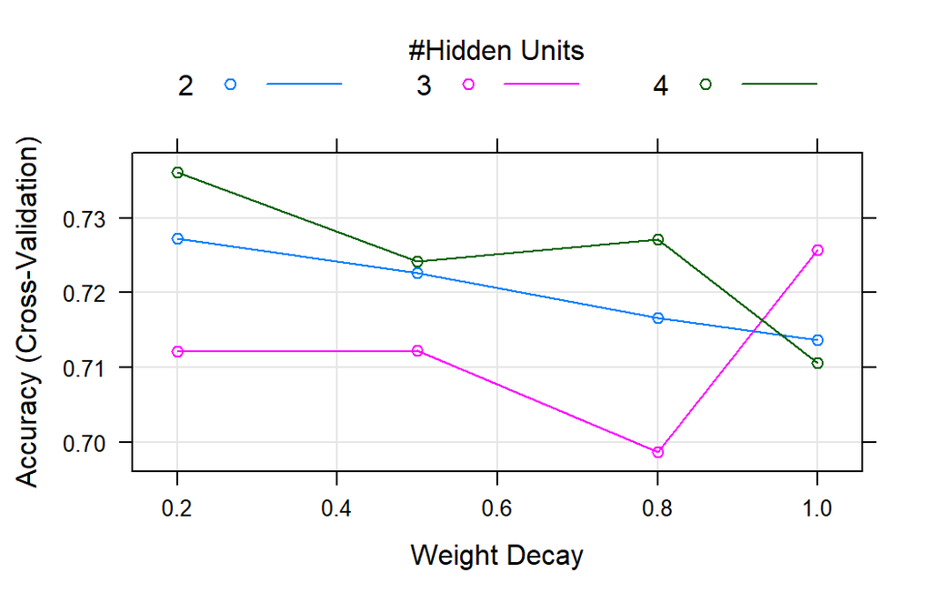

```r
plot(model.nn1)
```

Nous regardons quelle covariable influnce le plus le modèle.

```r
varImp(model.nn1)
```

```
## nnet variable importance
##
##   only 20 most important variables shown (out of 73)
##
##                                           Overall
## Credit.Amount                             100.000
## Age.years                                   9.475
## Statusnone                                  5.119
## Instalment.per.cent                         4.293
## No.of.dependents                            4.083
## Credit.Amount.log                           3.911
## Length.of.current.employment1.to.4          3.838
## Duration.norm                               3.787
## Duration.in.Current.address                 3.666
## Status0.to.200                              3.636
## Credit.Amount.cat                           3.622
## HousingForFree                              3.435
## PurposeDomesticAppliance                    3.357
## JobUnskilledResident                        2.855
## `Savings account/bonds`gt.1000              2.755
## HistorythisBank.AllPaid                     2.674
## Duration                                    2.453
## Job.newManagement.SelfEmp.HighlyQualified   2.400
## JobManagement.SelfEmp.HighlyQualified       2.394
## Credit.Amount.norm                          2.359
```

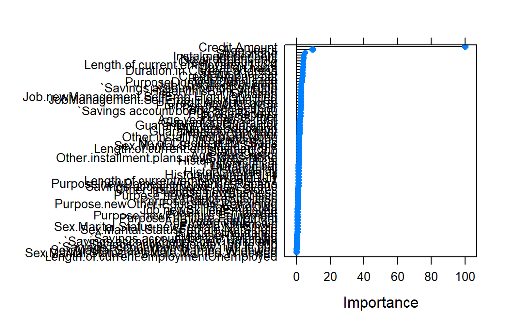

```r
plot(varImp(model.nn1))
```

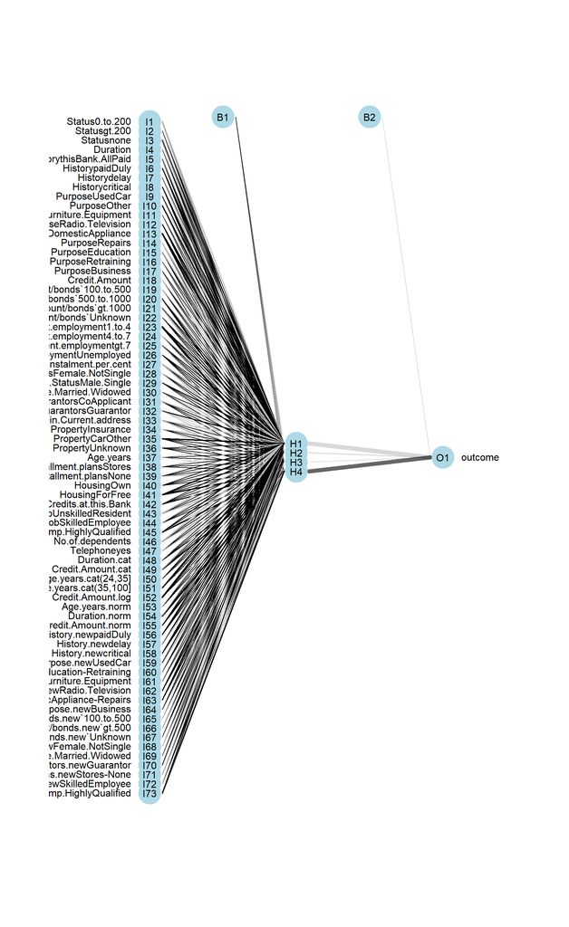

```r
library(NeuralNetTools) #Neurone schéma
library(neuralnet)
library(nnet)# neuronalnetwork nnet
plotnet(model.nn1, y_names = "outcome",pad_x = 0.8,pad_y = 1, alpha = 0.6,)
```